# Lab 2 Question Set

Hexiang Zhang & Ashley Anderson

9/12/2019

Github Repo: https://github.com/ashleyna7/ds202_lab2 Repo Name: ds202_lab2 Owner username: ashleyna7

#### Partner 1: Ashley Anderson

#### Partner 2: Hexiang Zhang

1 . Run the following code line by line to figure out what it’s doing. Then next to each line of code, write a comment explaining its purpose and function, including the use of any specific arguments. Comments in R are proceeded by a `#`, so that R knows not to run anything after the hashtag.

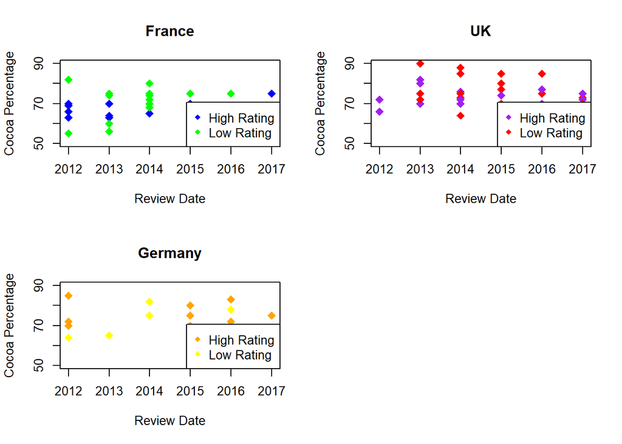

```r
recent_rating = choco[choco$Review.Date>2011,] #Creates data frame of all ratings after 2011.

unique(recent_rating$Company.Location) #Levels lists all countries present from the original data set, while unique lists all the unique country names in the recent_rating data set, deleteing duplicates. There are 61 levels, and 54 unqiue countries in recent_rating.

recent_rating$Company.Location = droplevels(recent_rating$Company.Location) #This drops all levels that are not in the recent_rating data set but were in the choco data set. Now there are 54 levels.

head(recent_rating) #This gives the first few rows of the data set.

cross_table = table(recent_rating$Review.Date,recent_rating$Company.Location)
cross_table #This counts the number of ratings a country has in each year.

which(cross_table[1,]!=0 & cross_table[2,]!=0 & cross_table[3,]!=0 & cross_table[4,]!=0 & cross_table[5,]!=0) #This gives all the country names and index locations that never have a count of 0 between 2012-1016.

france_recent = subset(recent_rating,Company.Location =='France')
uk_recent = subset(recent_rating,Company.Location =='U.K.')
germany_recent = subset(recent_rating,Company.Location=='Germany') #These 3 lines of code filters the recent_rating data frame by the company location of France, UK, and Germany respectively.

par(mfrow=c(2,2))
color1 = ifelse(france_recent$Rating >median(france_recent$Rating), 'blue', 'green')
plot(france_recent$Cocoa.Pct ~ france_recent$Review.Date,ylim=c(50,90),col=color1,pch=18,cex=1.5,xlab="Review Date", ylab= "Cocoa Percentage", main= "France")
legend('bottomright',legend=c('High Rating', 'Low Rating'),col=c('blue','green'),pch=18)

color2 = ifelse(uk_recent$Rating >median(uk_recent$Rating), 'purple', 'red')
plot(uk_recent$Cocoa.Pct ~ uk_recent$Review.Date,ylim=c(50,90),col=color2,pch=18,cex=1.5, xlab="Review Date", ylab= "Cocoa Percentage", main= "UK")
legend('bottomright',legend=c('High Rating', 'Low Rating'),col=c('purple','red'),pch=18)

color3 = ifelse(germany_recent$Rating > median(germany_recent$Rating), 'orange', 'yellow')
plot(germany_recent$Cocoa.Pct ~ germany_recent$Review.Date,ylim=c(50,90),col=color3,pch=18,cex=1.5,xlab="Review Date", ylab= "Cocoa Percentage", main= "Germany")
legend('bottomright',legend=c('High Rating', 'Low Rating'),col=c('orange','yellow'),pch=18)

#These 3 chunks of code create 3 separate graphs in one 2x2 window. These graphs show the review years by cocoa percentage. If the rating is above the median, it is labeled as high rating. Otherwise, it is labeled at low rating. Each graph also has unqiue colors to further identify.
```

2 . Click Zoom on the Rstudio window (under Plots) to see the plot more clearly. How do you think the plot produced from the code above can be improved? Recommend at least one possible improvement.

Add trend lines by rating so there is two trend lines per graph. This would make it easier to compare the two ratings and see how they improve overtime by country. It is also difficult to compare countries because the median values differ. You can’t compare across graphs, so using a 2x2 window is misleading a little bit.

3 . How does the **number** of ratings (not the actual value of the rating) depend on the year? Use graphics to answer this question.

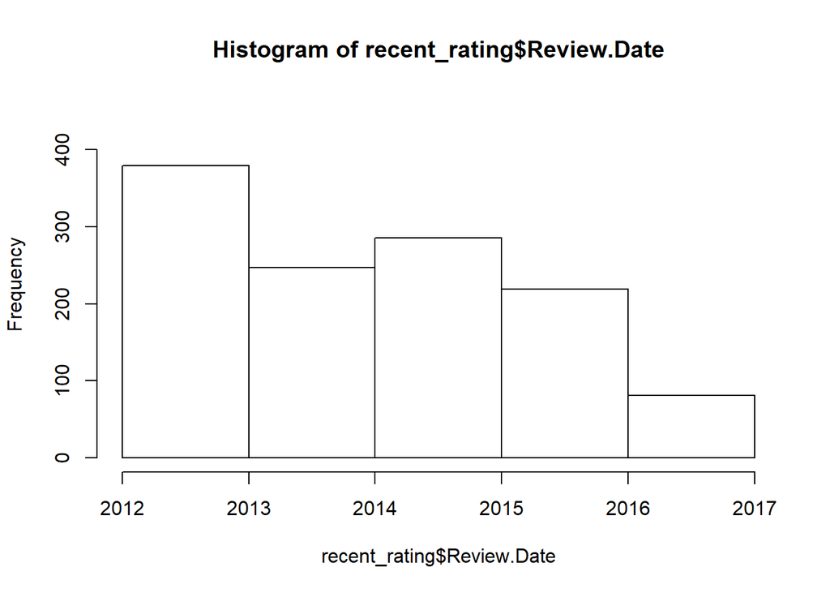

```r
hist(recent_rating$Review.Date, breaks=6, ylim=c(0,450))
```

We can see that the total number of ratings decreases as time goes on. In the histogram, there are significantly more ratings in between 2012 and 2013 (~400) than 2016 to 2017 (~100).

4 . How do ratings compare across different company locations? Focus on the three locations with the most ratings. Hint: the function `sort()` might come in handy here.

```r
sort(table(recent_rating$Company.Location), decreasing = TRUE)[1:3]
```

```
##
## U.S.A. Canada France
##    583    108     69
```

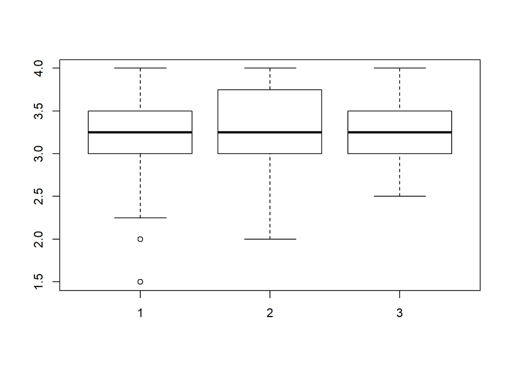

```r
us_recent = subset(recent_rating,Company.Location =='U.S.A.')
canada_recent = subset(recent_rating, Company.Location =='Canada')
france_recent = subset(recent_rating,Company.Location =='France')

boxplot(us_recent$Rating, canada_recent$Rating, france_recent$Rating)
```

The three locations with the most ratings are USA, Canada, and France. Overall, the median of ratings are similar between the 3 locations. They have similar first quartiles. Canada has the highest third quartile. The boxplots for USA and France are similar.

5 . Brainstorm and write down an interesting question that can be answer from the dataset. The question should not duplicate the questions above.

How does the cocoa percentage depend on the year of review?

6 . Bonus points (optional): Answer the question from the dataset.

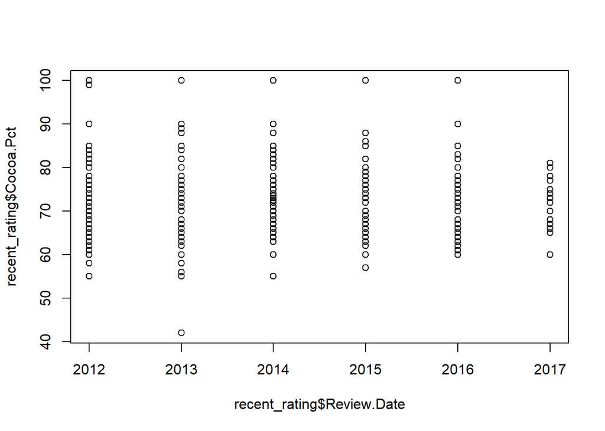

```r
plot(recent_rating$Review.Date,recent_rating$Cocoa.Pct)
```

It appears that the distribution of cocoa percentage decreases as time goes on. For example, the range of cocoa percentage in 2012 is between 55-100 while the range of cocoa percentage in 2017 is about 60-85.